# Network Trafic Classification

In the modern era of technology, computer networks have become the backbone of communication, powering industries, governments, and individual users across the globe. The concept of networking involves interconnecting devices to enable the seamless transfer of data, whether for browsing the internet, streaming videos, or supporting critical applications such as online banking and healthcare systems.

With the exponential increase in data generation, managing and optimizing network performance has become a challenging yet vital task. Traditional approaches to network management often involve manual analysis and rule-based systems that are time-consuming and prone to inaccuracies. As the number of connected devices grows, networks are flooded with diverse types of traffic, each requiring different levels of priority and security. This complexity necessitates advanced methods to monitor, classify, and manage network traffic efficiently.

Machine learning (ML) has emerged as a transformative tool in the field of networking, offering automated and accurate solutions for traffic classification, anomaly detection, and performance optimization. Unlike traditional rule-based methods, ML algorithms can learn patterns from historical data, adapt to new traffic types, and identify previously unseen network behaviors. The integration of ML into network management promises a paradigm shift, enabling smarter and more reliable networking solutions.

### 1. Data Collection

o Using tools like Wireshark or Tshark to capture network packets. o Saving the captured packets in a format like .pcap and(or) converting them to a CSV for easier processing.

### 2. Feature Extraction

o Extracting meaningful features such as packet size, protocol type, source/destination IP, and time interval between packets. o Useful Tools: Python libraries like Scapy or PyShark.

### 3. Data Preprocessing

o Cleansing and normalizing the data. o Spliting the dataset into training and testing subsets.

### 4. Model Development

o Using a Python library like Scikit-learn or TensorFlow to build the machine learning model. o Algorithms: Random Forest, SVM, or Neural Networks (depending on complexity).

### 5. Training and Testing

o Training the model using the training dataset. o Evaluating its accuracy using metrics like precision, recall, F1-score, and confusion matrix.

### 6. Visualization

o Using libraries like matplotlib or seaborn to visualize traffic patterns and classification results.

```python
import pandas as pd
import numpy as np
from sklearn.model_selection import train_test_split
from sklearn.preprocessing import LabelEncoder, StandardScaler
from sklearn.linear_model import LogisticRegression
from sklearn.ensemble import RandomForestClassifier
from sklearn.svm import SVC
from sklearn.neighbors import KNeighborsClassifier
from sklearn.tree import DecisionTreeClassifier
from sklearn.metrics import classification_report, confusion_matrix, accuracy_score
import seaborn as sns
import matplotlib.pyplot as plt
from tensorflow.keras.models import Sequential
from tensorflow.keras.layers import Dense
```

### Loading Data

```python
import warnings

# Suppress all warnings
warnings.filterwarnings("ignore")

# Load the dataset
data = pd.read_csv("network_Packets.csv")

# Display first few rows of the dataset
print("Dataset preview:")
print(data.head())
```

```
Dataset preview:
   No.      Time          Source     Destination Protocol  Length  \
0    1  0.000000  20.198.167.116     192.168.1.4      TCP      54
1    2  0.001578     192.168.1.4  52.167.249.196      TCP      66
2    3  0.264585  52.167.249.196     192.168.1.4      TCP      66
3    4  0.264655     192.168.1.4  52.167.249.196      TCP      54
4    5  0.265467     192.168.1.4  52.167.249.196  TLSv1.2     270

                                                Info
0        443  >  4263 [ACK] Seq=1 Ack=1 Win=63 Len=0
1  4280  >  443 [SYN] Seq=0 Win=64240 Len=0 MSS=1...
2  443  >  4280 [SYN, ACK] Seq=0 Ack=1 Win=65535 ...
3    4280  >  443 [ACK] Seq=1 Ack=1 Win=132352 Len=0
4  Client Hello (SNI=settings-win.data.microsoft....
```

```python
data.head()
```

|  | No. | Time | Source | Destination | Protocol | Length | Info |
| --- | --- | --- | --- | --- | --- | --- | --- |
| 0 | 1 | 0.000000 | 20.198.167.116 | 192.168.1.4 | TCP | 54 | 443 > 4263 [ACK] Seq=1 Ack=1 Win=63 Len=0 |
| 1 | 2 | 0.001578 | 192.168.1.4 | 52.167.249.196 | TCP | 66 | 4280 > 443 [SYN] Seq=0 Win=64240 Len=0 MSS=1... |
| 2 | 3 | 0.264585 | 52.167.249.196 | 192.168.1.4 | TCP | 66 | 443 > 4280 [SYN, ACK] Seq=0 Ack=1 Win=65535 ... |
| 3 | 4 | 0.264655 | 192.168.1.4 | 52.167.249.196 | TCP | 54 | 4280 > 443 [ACK] Seq=1 Ack=1 Win=132352 Len=0 |
| 4 | 5 | 0.265467 | 192.168.1.4 | 52.167.249.196 | TLSv1.2 | 270 | Client Hello (SNI=settings-win.data.microsoft.... |

### Categorising Traffic

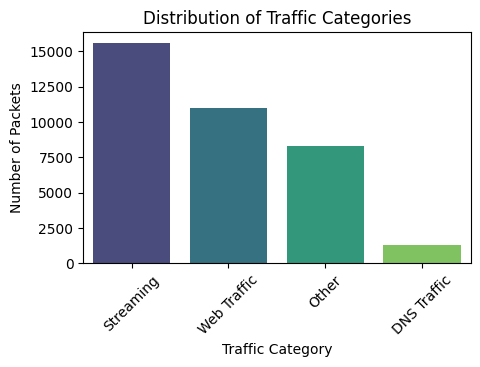

```python
# Traffic categorization
protocol_mapping = {
    'TCP': 'Web Traffic',
    'UDP': 'DNS Traffic',
    'ICMP': 'Network Diagnostics',
    'QUIC': 'Streaming'
}

# Mapping protocol names to categories
if 'Protocol' in data.columns:
    data['Protocol_Category'] = data['Protocol'].map(protocol_mapping).fillna('Other')

# Visualize the distribution of traffic categories
plt.figure(figsize=(5, 3))
traffic_counts = data['Protocol_Category'].value_counts()
sns.barplot(x=traffic_counts.index, y=traffic_counts.values, palette="viridis")
plt.title("Distribution of Traffic Categories")
plt.xlabel("Traffic Category")
plt.ylabel("Number of Packets")
plt.xticks(rotation=45)
plt.show()
```

### Data Processing

```python
# Load the dataset
data = pd.read_csv("network_Packets.csv")

# Display first few rows of the dataset
print("Dataset preview:")
print(data.head())
# Dropping unnecessary columns
if 'No.' in data.columns:
    data.drop('No.', axis=1, inplace=True)

# Encode categorical columns ('Source', 'Destination', 'Protocol', 'Info') using LabelEncoder
categorical_columns = ['Source', 'Destination', 'Protocol', 'Info']
label_encoders = {}

for col in categorical_columns:
    if col in data.columns:
        le = LabelEncoder()
        data[col] = le.fit_transform(data[col])
        label_encoders[col] = le
```

```
Dataset preview:
   No.      Time          Source     Destination Protocol  Length  \
0    1  0.000000  20.198.167.116     192.168.1.4      TCP      54
1    2  0.001578     192.168.1.4  52.167.249.196      TCP      66
2    3  0.264585  52.167.249.196     192.168.1.4      TCP      66
3    4  0.264655     192.168.1.4  52.167.249.196      TCP      54
4    5  0.265467     192.168.1.4  52.167.249.196  TLSv1.2     270

                                                Info
0        443  >  4263 [ACK] Seq=1 Ack=1 Win=63 Len=0
1  4280  >  443 [SYN] Seq=0 Win=64240 Len=0 MSS=1...
2  443  >  4280 [SYN, ACK] Seq=0 Ack=1 Win=65535 ...
3    4280  >  443 [ACK] Seq=1 Ack=1 Win=132352 Len=0
4  Client Hello (SNI=settings-win.data.microsoft....
```

### Train-Test Spliting Data

```python
# Define features (X) and target (y)
X = data.drop('Protocol', axis=1)  # Using 'Protocol' as the target column (you can adjust as needed)
y = data['Protocol']

# Standardize numerical features
scaler = StandardScaler()
X_scaled = scaler.fit_transform(X)

# Train-test split
X_train, X_test, y_train, y_test = train_test_split(X_scaled, y, test_size=0.3, random_state=42)
```

### Initializing Model

```python
# Initialize models
models = {
    "Logistic Regression": LogisticRegression(max_iter=1000),
    "Random Forest": RandomForestClassifier(),
    "SVM": SVC(),
    "KNN": KNeighborsClassifier(),
    "Decision Tree": DecisionTreeClassifier()
}
```

### Evaluating Model

#### LogisticRegression model

```python
# Train and evaluate models
results = {}
accuracies = []

# Initialize the model
logistic_model = LogisticRegression(max_iter=1000)

# Train the model
logistic_model.fit(X_train, y_train)

# Predict
y_pred = logistic_model.predict(X_test)

# Evaluate
print("Logistic Regression Accuracy:", accuracy_score(y_test, y_pred))
print("Classification Report:\n", classification_report(y_test, y_pred))
```

```
Logistic Regression Accuracy: 0.8001103854291234
Classification Report:
               precision    recall  f1-score   support

           0       0.75      0.50      0.60        12
           1       0.00      0.00      0.00         1
           3       0.00      0.00      0.00       171
           4       0.00      0.00      0.00         4
           5       0.78      1.00      0.88        77
           6       0.00      0.00      0.00         1
           7       0.79      0.98      0.87      4713
           8       0.00      0.00      0.00         4
           9       0.82      0.86      0.84      3274
          10       0.83      0.83      0.83       818
          11       0.80      0.35      0.48      1394
          12       0.92      0.09      0.16       402

    accuracy                           0.80     10871
   macro avg       0.47      0.38      0.39     10871
weighted avg       0.80      0.80      0.77     10871
```

### Random Forest

```python
# Initialize the model
rf_model = RandomForestClassifier(n_estimators=100, random_state=42)

# Train the model
rf_model.fit(X_train, y_train)

# Predict
y_pred = rf_model.predict(X_test)

# Evaluate
print("Random Forest Accuracy:", accuracy_score(y_test, y_pred))
print("Classification Report:\n", classification_report(y_test, y_pred))
```

```
Random Forest Accuracy: 0.9946647042590379
Classification Report:
               precision    recall  f1-score   support

           0       1.00      1.00      1.00        12
           1       1.00      1.00      1.00         1
           3       1.00      1.00      1.00       171
           4       1.00      1.00      1.00         4
           5       1.00      1.00      1.00        77
           6       1.00      1.00      1.00         1
           7       1.00      1.00      1.00      4713
           8       1.00      1.00      1.00         4
           9       1.00      1.00      1.00      3274
          10       0.97      0.96      0.97       818
          11       0.98      0.98      0.98      1394
          12       1.00      1.00      1.00       402

    accuracy                           0.99     10871
   macro avg       1.00      1.00      1.00     10871
weighted avg       0.99      0.99      0.99     10871
```

### Support Vector Machine (SVM)

A Support Vector Machine (SVM) is a supervised machine learning algorithm used for classification and regression tasks. It works by finding the optimal hyperplane that separates data points of different classes in a feature space. SVM is widely known for its effectiveness in handling high-dimensional datasets and its ability to create robust decision boundaries.

```python
# Initialize the model
svm_model = SVC(kernel='linear')

# Train the model
svm_model.fit(X_train, y_train)

# Predict
y_pred = svm_model.predict(X_test)

# Evaluate
print("SVM Accuracy:", accuracy_score(y_test, y_pred))
print("Classification Report:\n", classification_report(y_test, y_pred))
```

```
SVM Accuracy: 0.8660656793303284
Classification Report:
               precision    recall  f1-score   support

           0       1.00      1.00      1.00        12
           1       0.00      0.00      0.00         1
           3       0.53      1.00      0.69       171
           4       0.00      0.00      0.00         4
           5       0.77      1.00      0.87        77
           6       0.00      0.00      0.00         1
           7       0.87      0.93      0.90      4713
           8       0.00      0.00      0.00         4
           9       0.98      0.88      0.93      3274
          10       0.89      0.81      0.85       818
          11       0.71      0.87      0.78      1394
          12       0.00      0.00      0.00       402

    accuracy                           0.87     10871
   macro avg       0.48      0.54      0.50     10871
weighted avg       0.85      0.87      0.85     10871
```

### K-Nearest Neighbour (KMM)

KNN classifies a sample based on the majority class of its nearest neighbors. It is simple and effective for smaller datasets.

```python
from sklearn.neighbors import KNeighborsClassifier

# Initialize the model
knn_model = KNeighborsClassifier(n_neighbors=5)

# Train the model
knn_model.fit(X_train, y_train)

# Predict
y_pred = knn_model.predict(X_test)

# Evaluate
print("KNN Accuracy:", accuracy_score(y_test, y_pred))
print("Classification Report:\n", classification_report(y_test, y_pred))
```

```
KNN Accuracy: 0.9822463434826603
Classification Report:
               precision    recall  f1-score   support

           0       1.00      1.00      1.00        12
           1       0.00      0.00      0.00         1
           3       0.99      1.00      0.99       171
           4       1.00      0.50      0.67         4
           5       0.93      1.00      0.96        77
           6       0.00      0.00      0.00         1
           7       0.99      0.99      0.99      4713
           8       1.00      1.00      1.00         4
           9       0.99      1.00      1.00      3274
          10       0.95      0.94      0.95       818
          11       0.95      0.94      0.94      1394
          12       0.96      0.99      0.98       402

    accuracy                           0.98     10871
   macro avg       0.81      0.78      0.79     10871
weighted avg       0.98      0.98      0.98     10871
```

### Decision tree Model

Decision Trees create a tree-like structure where decisions are made at nodes based on feature values. They are interpretable and effective for simple datasets.

```python
# Initialize the model
dt_model = DecisionTreeClassifier(random_state=42)

# Train the model
dt_model.fit(X_train, y_train)

# Predict
y_pred = dt_model.predict(X_test)

# Evaluate
print("Decision Tree Accuracy:", accuracy_score(y_test, y_pred))
print("Classification Report:\n", classification_report(y_test, y_pred))
```

```
Decision Tree Accuracy: 0.9965964492686965
Classification Report:
               precision    recall  f1-score   support

           0       1.00      1.00      1.00        12
           1       1.00      1.00      1.00         1
           3       1.00      1.00      1.00       171
           4       1.00      0.50      0.67         4
           5       1.00      1.00      1.00        77
           6       1.00      1.00      1.00         1
           7       1.00      1.00      1.00      4713
           8       0.67      1.00      0.80         4
           9       1.00      1.00      1.00      3274
          10       0.98      0.97      0.98       818
          11       0.98      0.99      0.99      1394
          12       1.00      1.00      1.00       402

    accuracy                           1.00     10871
   macro avg       0.97      0.96      0.95     10871
weighted avg       1.00      1.00      1.00     10871
```

### Nural Network

Neural networks, a subset of deep learning, are powerful for handling complex and high-dimensional datasets. They are especially useful for non-linear problems.

```python
# Initialize the model
nn_model = Sequential([
    Dense(128, activation='relu', input_dim=X_train.shape[1]),
    Dense(64, activation='relu'),
    Dense(len(y_train.unique()), activation='softmax')  # For multi-class classification
])

# Compile the model
nn_model.compile(optimizer='adam', loss='sparse_categorical_crossentropy', metrics=['accuracy'])

# Train the model
nn_model.fit(X_train, y_train, epochs=10, batch_size=32, validation_data=(X_test, y_test))

# Evaluate
loss, accuracy = nn_model.evaluate(X_test, y_test)
print("Neural Network Accuracy:", accuracy)
```

```
793/793 ━━━━━━━━━━━━━━━━━━━━ 8s 2ms/step - accuracy: 0.7517 - loss: 0.9141 - val_accuracy: 0.9145 - val_loss: 0.2933
793/793 ━━━━━━━━━━━━━━━━━━━━ 1s 1ms/step - accuracy: 0.9286 - loss: 0.2472 - val_accuracy: 0.9520 - val_loss: 0.1804
793/793 ━━━━━━━━━━━━━━━━━━━━ 1s 1ms/step - accuracy: 0.9557 - loss: 0.1618 - val_accuracy: 0.9621 - val_loss: 0.1381
793/793 ━━━━━━━━━━━━━━━━━━━━ 1s 1ms/step - accuracy: 0.9639 - loss: 0.1285 - val_accuracy: 0.9634 - val_loss: 0.1299
793/793 ━━━━━━━━━━━━━━━━━━━━ 1s 1ms/step - accuracy: 0.9665 - loss: 0.1153 - val_accuracy: 0.9703 - val_loss: 0.1065
793/793 ━━━━━━━━━━━━━━━━━━━━ 1s 1ms/step - accuracy: 0.9724 - loss: 0.0995 - val_accuracy: 0.9686 - val_loss: 0.1022
793/793 ━━━━━━━━━━━━━━━━━━━━ 1s 1ms/step - accuracy: 0.9740 - loss: 0.0875 - val_accuracy: 0.9744 - val_loss: 0.0866
793/793 ━━━━━━━━━━━━━━━━━━━━ 1s 1ms/step - accuracy: 0.9755 - loss: 0.0818 - val_accuracy: 0.9713 - val_loss: 0.0880
793/793 ━━━━━━━━━━━━━━━━━━━━ 1s 1ms/step - accuracy: 0.9765 - loss: 0.0759 - val_accuracy: 0.9788 - val_loss: 0.0730
793/793 ━━━━━━━━━━━━━━━━━━━━ 1s 1ms/step - accuracy: 0.9768 - loss: 0.0694 - val_accuracy: 0.9780 - val_loss: 0.0766
340/340 ━━━━━━━━━━━━━━━━━━━━ 0s 708us/step - accuracy: 0.9756 - loss: 0.0803
Neural Network Accuracy: 0.9780148863792419
```

### Performance Comparison

```python
# Store model performances
results = {
    'Logistic Regression': logistic_model.score(X_test, y_test),
    'Random Forest': rf_model.score(X_test, y_test),
    'SVM': svm_model.score(X_test, y_test),
    'KNN': knn_model.score(X_test, y_test),
    'Decision Tree': dt_model.score(X_test, y_test)
}

# Print results
for model_name, accuracy in results.items():
    print(f"{model_name}: {accuracy:.2f}")
```

```
Logistic Regression: 0.80
Random Forest: 0.99
SVM: 0.87
KNN: 0.98
Decision Tree: 1.00
```

### Visualizing Performance

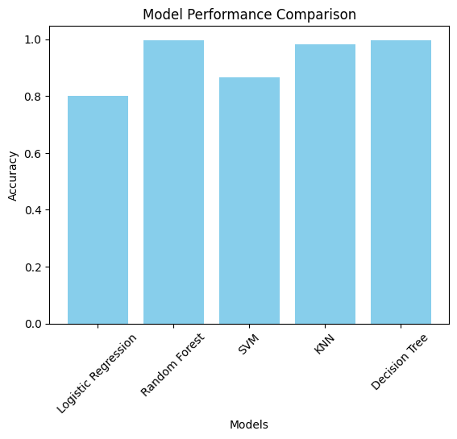

```python
# Plot accuracies
plt.bar(results.keys(), results.values(), color='skyblue')
plt.xlabel('Models')
plt.ylabel('Accuracy')
plt.title('Model Performance Comparison')
plt.xticks(rotation=45)
plt.show()
```

### Confusion Matrix

```python
for model_name, model in models.items():
    print(f"Training {model_name}...")
    model.fit(X_train, y_train)
    y_pred = model.predict(X_test)

    # Calculate accuracy
    accuracy = accuracy_score(y_test, y_pred)
    accuracies.append((model_name, accuracy))

    # Store results
    results[model_name] = {
        "Confusion Matrix": confusion_matrix(y_test, y_pred),
        "Classification Report": classification_report(y_test, y_pred, output_dict=True),
        "Accuracy": accuracy
    }

    print(f"{model_name} Classification Report:")
    print(classification_report(y_test, y_pred))
```

```
Training Logistic Regression...
Logistic Regression Classification Report:
              precision    recall  f1-score   support

           0       0.75      0.50      0.60        12
           1       0.00      0.00      0.00         1
           3       0.00      0.00      0.00       171
           4       0.00      0.00      0.00         4
           5       0.78      1.00      0.88        77
           6       0.00      0.00      0.00         1
           7       0.79      0.98      0.87      4713
           8       0.00      0.00      0.00         4
           9       0.82      0.86      0.84      3274
          10       0.83      0.83      0.83       818
          11       0.80      0.35      0.48      1394
          12       0.92      0.09      0.16       402

    accuracy                           0.80     10871
   macro avg       0.47      0.38      0.39     10871
weighted avg       0.80      0.80      0.77     10871

Training Random Forest...
Random Forest Classification Report:
              precision    recall  f1-score   support

           0       1.00      1.00      1.00        12
           1       1.00      1.00      1.00         1
           3       1.00      1.00      1.00       171
           4       1.00      1.00      1.00         4
           5       1.00      1.00      1.00        77
           6       1.00      1.00      1.00         1
           7       1.00      1.00      1.00      4713
           8       1.00      1.00      1.00         4
           9       1.00      1.00      1.00      3274
          10       0.97      0.96      0.97       818
          11       0.98      0.98      0.98      1394
          12       1.00      1.00      1.00       402

    accuracy                           0.99     10871
   macro avg       1.00      1.00      1.00     10871
```

[output cut: 49 more lines]

```
           1       1.00      1.00      1.00         1
           3       1.00      1.00      1.00       171
           4       1.00      0.50      0.67         4
           5       1.00      1.00      1.00        77
           6       1.00      1.00      1.00         1
           7       1.00      1.00      1.00      4713
           8       0.67      1.00      0.80         4
           9       1.00      1.00      1.00      3274
          10       0.98      0.97      0.98       818
          11       0.98      0.99      0.99      1394
          12       1.00      1.00      1.00       402

    accuracy                           1.00     10871
   macro avg       0.97      0.95      0.95     10871
weighted avg       1.00      1.00      1.00     10871
```

### Visualizing Confusion Matrix

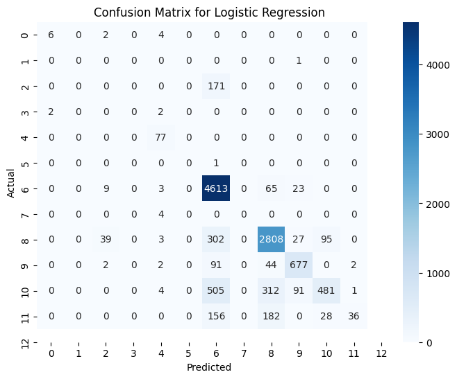

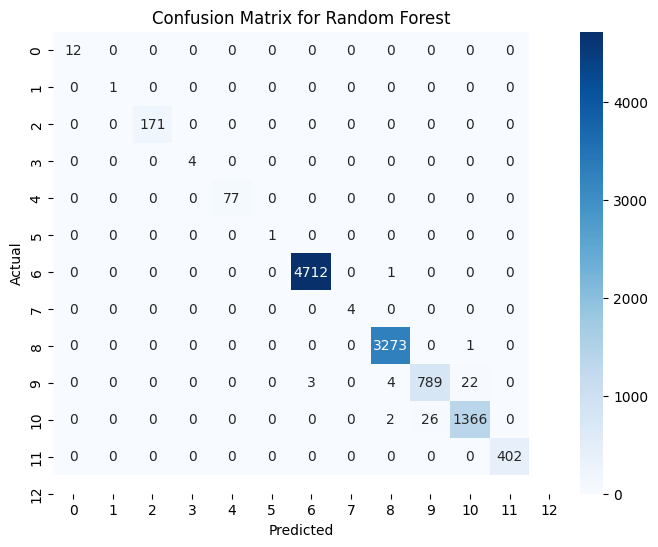

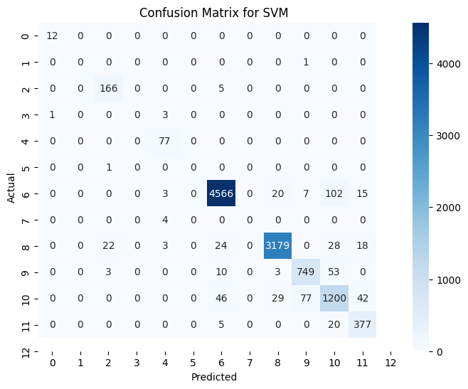

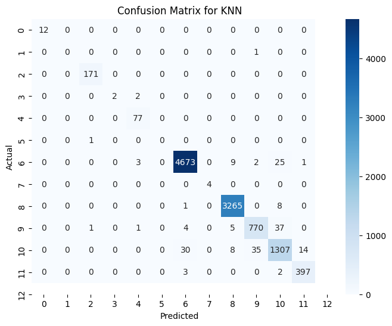

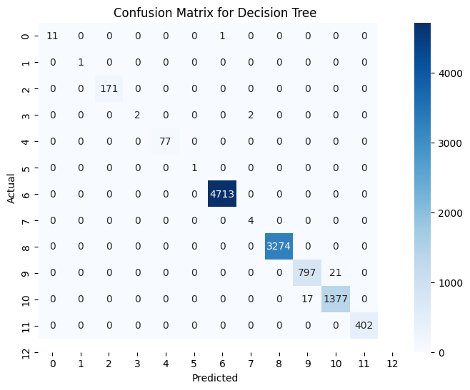

```python
# Visualization: Confusion Matrices
for model_name, result in results.items():
    cm = result["Confusion Matrix"]
    plt.figure(figsize=(8, 6))
    sns.heatmap(cm, annot=True, fmt='d', cmap='Blues', xticklabels=np.unique(y), yticklabels=np.unique(y))
    plt.title(f"Confusion Matrix for {model_name}")
    plt.xlabel("Predicted")
    plt.ylabel("Actual")
    plt.show()
```

### Accuracy Comparison

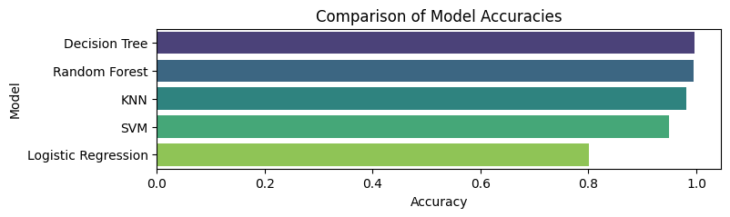

```python
# Visualization: Bar Graph of Model Accuracies
accuracies = sorted(accuracies, key=lambda x: x[1], reverse=True)
model_names = [x[0] for x in accuracies]
accuracy_values = [x[1] for x in accuracies]
plt.figure(figsize=(8, 2))
sns.barplot(x=accuracy_values, y=model_names, palette="viridis")
plt.title("Comparison of Model Accuracies")
plt.xlabel("Accuracy")
plt.ylabel("Model")
plt.show()
```

### Model Accuracies

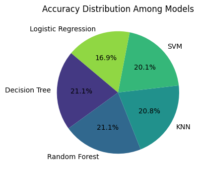

```python
# Visualization: Pie Chart of Model Accuracies
plt.figure(figsize=(4, 4))
plt.pie(accuracy_values, labels=model_names, autopct="%1.1f%%", startangle=140, colors=sns.color_palette("viridis", len(models)))
plt.title("Accuracy Distribution Among Models")
plt.show()
```